# Project One

Mingyi Wang 730268300

9/16/2018

# 1. `msleep`

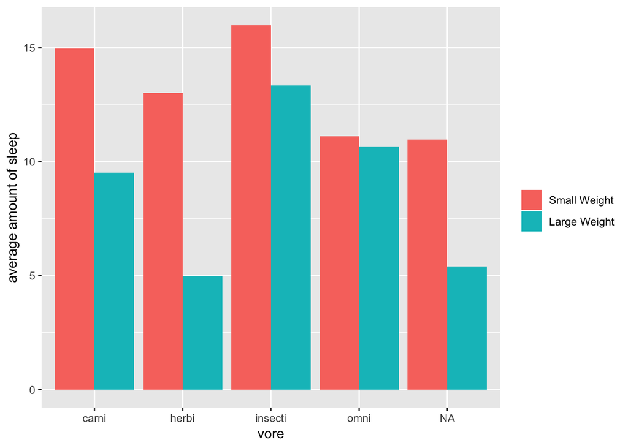

> This figure was derived from the “msleep” data set in R, which is taken from a quantitative, theoretical study of mammalian sleep. The data set contains 83 obersavations (different mammals) within 4 types of vores(carnivore, omivore, herbivore and insectivore). The average total sleep time of all mammals is 10.43 hours per day. But it is interesting to find that the body weight of mammals has something to do with sleep. Small weight mammals sleep 4.25 hours more than large weight mammals per day in average. Giraffe sleeps least with 1.9 hours per day, pilot whale is the second least with 2.7 hours per day. However, thick-tailed opposum and little brown bat use almost 83.3% of their life sleeping.

> For future steps, we could try to figure out the relationship between sleep cycle and conservation. Also, if possible, we can collect more data on genus (or genes) which might be helpful to figure out what kind of genes contribute to sleep.

# 2. `Storms`

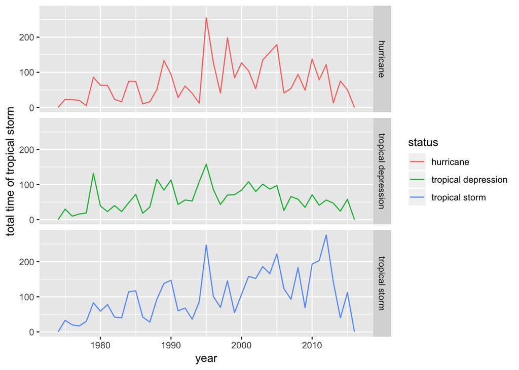

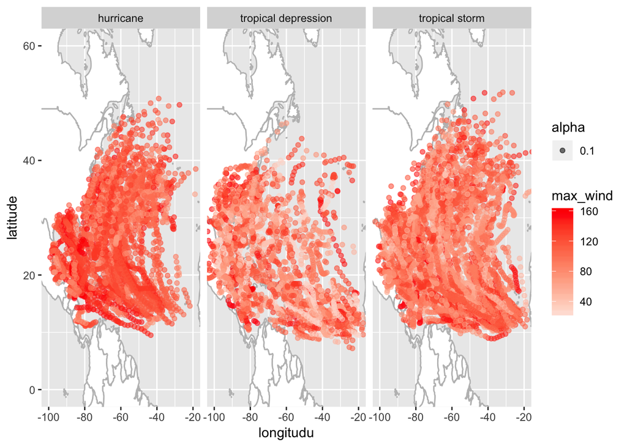

> From this plot,we can see that the maximum wind speed of hurricane (85.97 in knots)is way faster than tropical depression(27.27 in knots) and tropical storm(45.81 in knots). Compared to the center of Atlantic Ocean, Hurricane is much stronger when it is close to the coastal area. And southern east coast in America endured more hurricane threat than northern east coast. Also, tropical storm happened more frequently than tropical depression which merely took place in the north.

> As the data set contains variables air pressure and diameter of the area experiencing tropical storm strengh winds, it might be interesing to see how the tropical storms evolve from formation to the last stage.

# 3. `Titanic`

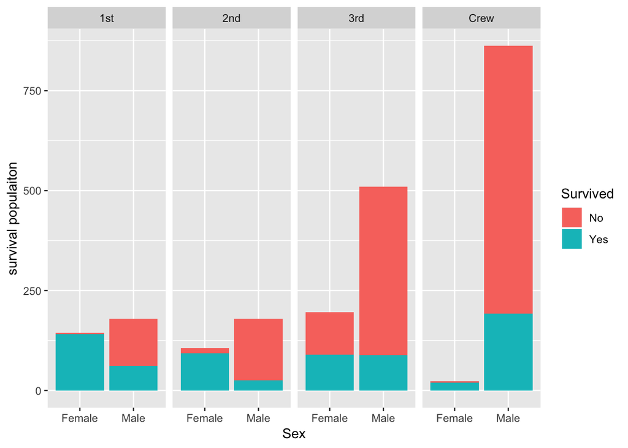

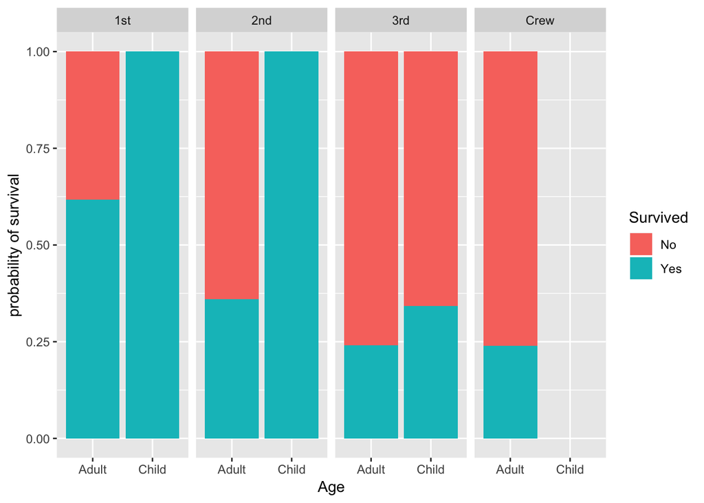

> As we all know, the ticket of the first class is more expensive than the second class and then the third. So the better class is supposed to be better equipped with not only entertainment facilities but also rescue equipments. However, what surprises me is the total survival number in the second class should be the least! It is only 50% of the survival number in crew class. It might be interesting to think about why this happened.

> Since recently more and more data on Titanic Sinking Affair are open on Internet, to do further analysis on this topic, I think we can look into more variabls like family size, cabin location and ticket fare to learn more about survival rate.

# 4. `txhousing`

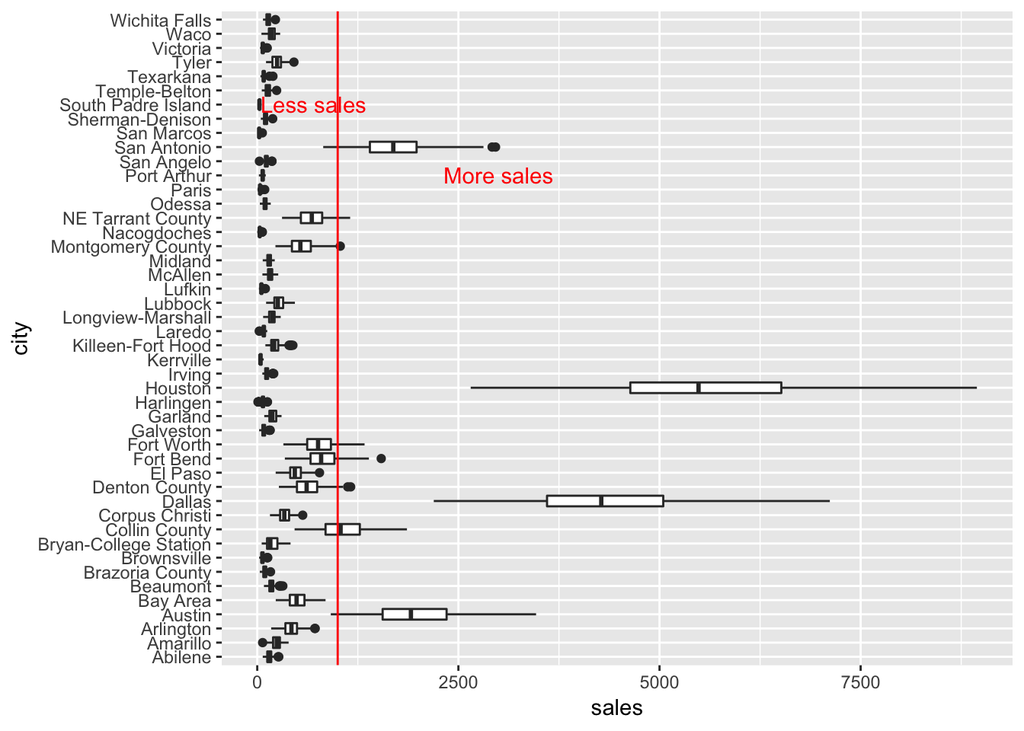

> As a next step, we can take a look at the relationship between “Median sale price” and “Number of sales”. Also, figuring out whether sale price relates to month would be interesting.